# M1-9: Supervised Machine Learning 2: Model boosting, diagnostics, explanation

# Model explainability

Machine learning (ML) models are often considered black boxes due to their complex inner-workings. More advanced ML models such as random forests, gradient boosting machines (GBM), artificial neural networks (ANN), among others are typically more accurate for predicting nonlinear, faint, or rare phenomena. Unfortunately, more accuracy often comes at the expense of interpretability, and interpretability is crucial for business adoption, model documentation, regulatory oversight, and human acceptance and trust. Luckily, several advancements have been made to aid in interpreting ML models.

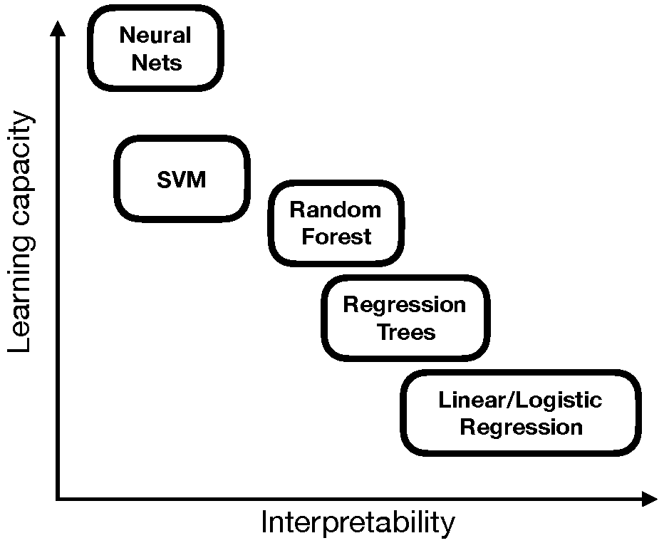

Moreover, it’s often important to understand the ML model that you’ve trained on a global scale, and also to zoom into local regions of your data or your predictions and derive local explanations.

- **Global interpretations** help us understand the inputs and their entire modeled relationship with the prediction target, but global interpretations can be highly approximate in some cases.
- **Local interpretation**s help us understand model predictions for a single row of data or a group of similar rows.

## Global explanation

Finally, let’s get a feeling what variables the models mostly draw from. There are numerous ways for such inspections, in which we will dewll deeper in later lectures. Here, I just want to present the most intuitive and common one, **Variable Importance**.

Most (but not all) model classes offer some possibility to derive measures of variable importance. Note, this is currently not implemented for SVMs. Again, in most ML models and setups, these meastures are nice to give a rough intuition, but CANNOT be interpreted as constant marginal effects, left alone causal.

```r
library(vip)
library(ggpubr)
ggarrange(vip(fit.rf) + ggtitle("VarImp: Random Forest"),
          vip(fit.nnet) + ggtitle("VarImp: Neural Network"),
          vip(fit.xgb) + ggtitle("VarImp: XG Boost"),
          ncol = 2, nrow = 2)
```

[output not shown]

[output not shown]

Note, for `xgboost`, there is a new `xgboostExplainer` package, which appartently does very well in global explanation. However, not tested yet.

## Local Explanation

### Introducing [`lime`](https://github.com/thomasp85/lime)

> *“There once was a package called lime, Whose models were simply sublime, It gave explanations for their variations, one observation at a time.”*

*lime-rick by Mara Averick*

**Local Interpretable Model-agnostic Explanations** (LIME) is a visualization technique that helps explain individual predictions. As the name implies, it is model agnostic so it can be applied to any supervised regression or classification model. The original paper is mindblowing, if you find time, just read it!

- Marco Tulio Ribeiro, Sameer Singh, and Carlos Guestrin. 2016. “”hy Should I Trust You?: Explaining the Predictions of Any Classifier." In Proceedings of the 22nd ACM SIGKDD International Conference on Knowledge Discovery and Data Mining (KDD 2016). ACM, New York, NY, USA, 1135-1144. DOI: https://doi.org/10.1145/2939672.2939778

Behind the workings of LIME lies the assumption that every complex model is linear on a local scale and asserting that it is possible to fit a simple model around a single observation that will mimic how the global model behaves at that locality. The simple model can then be used to explain the predictions of the more complex model locally.

The generalized algorithm LIME applies is:

1. Given an observation, permute it to create replicated feature data with slight value modifications.
2. Compute similarity distance measure between original observation and permuted observations.
3. Apply selected machine learning model to predict outcomes of permuted data.
4. Select m number of features to best describe predicted outcomes.
5. Fit a simple model to the permuted data, explaining the complex model outcome with m features from the permuted data weighted by its similarity to the original observation .
6. Use the resulting feature weights to explain local behavior.

### Dermonstration

To start with, an *in-build* illustration on image data (waif for M4!)

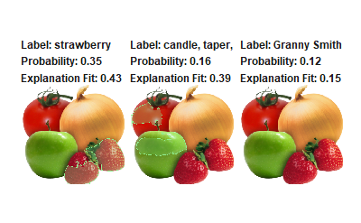

```r
library(lime)
explanation <- .load_image_example()
plot_image_explanation(explanation)
```

Ok, now we create or `lime()` object just by giving the function our (in this case random forest) fitted `caret` model, and the original data.

```r
limel.rf<- lime(x_train, fit.rf)
```

Once we created our lime objects, we can now perform the generalized LIME algorithm using the `explain()` function.

```r
explained.rf <-  explain(x = x_test %>% sample_n(8),
                         explainer = limel.rf,
                         n_permutations = 5000,
                         dist_fun = "gower",
                         kernel_width = 0.75,
                         n_features = 10,
                         feature_select = "highest_weights",
                         n_labels = 1 # to have the predicted class as baseline
                         # labels = "Yes" # to have te positive class as baseline
                         )
```

The `explain` function above first creates permutations, then calculates similarities, followed by selecting the m features. Lastly, explain will then fit a model. `lime` applies a ridge regression model (a subgroup of elastic nets) with the weighted permuted observations as the simple model.If the model is a regressor, the simple model will predict the output of the complex model directly. If the complex model is a classifier, the simple model will predict the probability of the chosen class(es).

The `explain` output is a data frame containing different information on the simple model predictions. Most importantly, for each observation it contains the simple model fit and the weighted importance (feature_weight) for each important feature that best describes the local relationship.

```r
explained.rf
```

[output not shown]

[output cut: 6 more lines]

However the simplest approach to interpret the results is to visualize them. There are several plotting functions provided by lime but for tabular data we are only concerned with two. The most important of which is `plot_features()`. This will create a visualization containing an individual plot for each observation (case 1, 2, …, n) in our data frame.

[figure not shown]

```r
plot_features(explained.rf)
```

Isn’t that super-cool???